# Ergebnisse kommunizieren

Praktische Übungen zum GRK2700 Statistik-Workshop

Autor:in

Dr. Dominic Schmitz

Veröffentlichungsdatum

25. August 2026

```r
library(ggplot2)
library(ggeffects)
library(lme4)
library(lmerTest)
library(SfL)

data("data_l", package = "SfL")
dat <- data_l

dat$condition <- relevel(
  factor(dat$condition),
  ref = "unrelated"
)

dat$length_z <- as.numeric(
  scale(dat$length)
)

m_comm <- lm(
  RT ~ frequency_z + condition + length_z,
  data = dat
)

m_int <- lm(
  RT ~ frequency_z * condition + length_z,
  data = dat
)

m_log <- glm(
  accuracy ~ frequency_z + condition,
  data = dat,
  family = binomial
)
```

**HinweisZiel dieses Blocks**

Nach der Analyse müssen wir aus einem komplexen statistischen Modell eine **verständliche wissenschaftliche Aussage** machen.

Dafür stehen uns vor allem drei Formen zur Verfügung:

- **Text**
- **Tabellen**
- **Abbildungen**

Idealerweise erzählen alle drei dieselbe Geschichte, ohne einander vollständig zu wiederholen.

In diesem Block üben wir deshalb nicht nur, *was* ein Modell sagt, sondern auch, **welche Information in welcher Darstellungsform am besten aufgehoben ist**.

# 1 Ergebnisse im Text berichten

## 1.1 Vom R-Output zur wissenschaftlichen Aussage

```r
summary(m_comm)
```

```
Call:
lm(formula = RT ~ frequency_z + condition + length_z, data = dat)

Residuals:
    Min      1Q  Median      3Q     Max
-445.77 -122.43  -25.52  100.62  918.97

Coefficients:
                 Estimate Std. Error t value Pr(>|t|)
(Intercept)       659.772      2.885 228.701  < 2e-16 ***
frequency_z       -40.451      2.687 -15.052  < 2e-16 ***
conditionrelated  -35.271      4.054  -8.700  < 2e-16 ***
length_z           18.580      2.511   7.399 1.52e-13 ***
---
Signif. codes:  0 '***' 0.001 '**' 0.01 '*' 0.05 '.' 0.1 ' ' 1

Residual standard error: 172 on 7196 degrees of freedom
Multiple R-squared:  0.08969,   Adjusted R-squared:  0.08931
F-statistic: 236.3 on 3 and 7196 DF,  p-value: < 2.2e-16
```

**HinweisAufgabe 1 · Was gehört überhaupt in den Ergebnissatz?**

geführt

Betrachte den Koeffizienten von `frequency_z`.

Welche der folgenden Informationen sind für einen guten Ergebnissatz grundsätzlich nützlich?

- Richtung des Zusammenhangs
- Größe des geschätzten Koeffizienten
- Unsicherheit der Schätzung
- Testergebnis
- persönliche Erklärung dafür, warum der Effekt entstanden ist
- theoretische Konsequenzen für die Literatur

**TippLösung**

In den **Ergebnisteil** gehören insbesondere:

- Richtung,
- Größe,
- Unsicherheit,
- Testergebnis.

Erklärungen, Literaturvergleich und theoretische Konsequenzen gehören normalerweise in die **Diskussion**.

Ergebnisse beantworten zunächst:

> **Was wurde gefunden und wie sicher ist diese Schätzung?**

## 1.2 Schlechter, besser, informativer

**HinweisAufgabe 2 · Drei Ergebnissätze redigieren**

geführt

Verbessere nacheinander diese Formulierungen:

1. „Es gab einen Effekt von Frequency.“
2. „Frequency beeinflusste die Reaktionszeit.“
3. „Frequency war signifikant.“

Formuliere am Ende einen Satz, der

- Richtung,
- ungefähre Größe,
- und die nicht-kausale Natur der Aussage

erkennen lässt.

**TippLösung**

Eine mögliche Formulierung ist:

> Mit zunehmender Wortfrequenz nahmen die Reaktionszeiten ab; ein Anstieg von `frequency_z` um eine Einheit ging im Modell bei konstant gehaltener Bedingung und Wortlänge mit einer Verringerung der vorhergesagten Reaktionszeit um etwa 40 ms einher.

Warum besser?

- **Richtung** ist explizit.
- **Größe** ist explizit.
- „ging einher“ behauptet keine Kausalität.
- Es wird deutlich, dass es sich um einen **konditionalen Modellkoeffizienten** handelt.

## 1.3 Kategoriale Prädiktoren verständlich berichten

**HinweisAufgabe 3 · Referenzkategorie nicht vergessen**

angewandt

Interpretiere den Koeffizienten `conditionrelated` aus `m_comm`.

Formuliere einen Satz, der auch ohne Kenntnis des R-Codes verständlich macht,

1. welche beiden Bedingungen verglichen werden,
2. welche die Referenzkategorie ist,
3. in welche Richtung der Unterschied geht.

**TippLösung**

Da `unrelated` die Referenzkategorie ist, beschreibt `conditionrelated` den Unterschied:

> **related minus unrelated**

Eine mögliche Formulierung:

> Wörter in der related-Bedingung wurden bei konstant gehaltener Wortfrequenz und Wortlänge im Mittel schneller erkannt als Wörter in der unrelated-Bedingung.

Für eine vollständige Ergebnisdarstellung würde anschließend noch die geschätzte Größe des Unterschieds und die Unsicherheit bzw. das Testergebnis ergänzt.

## 1.4 Nicht-signifikant heißt nicht „kein Effekt“

**HinweisAufgabe 4 · Sprachliche Präzision**

geführt

Welche Formulierung ist besser?

A. „Es gab keinen Effekt von X.“  
B. „Der Effekt von X war nicht signifikant.“  
C. „Für X ergab sich keine hinreichende Evidenz für einen Effekt.“

Warum?

**TippLösung**

**C** ist am vorsichtigsten.

Ein nicht-signifikantes Ergebnis zeigt nicht, dass der wahre Effekt exakt 0 ist. Es zeigt zunächst, dass die Daten unter der verwendeten Analyse **keine hinreichende Evidenz** für einen Effekt liefern.

Gerade bei breiten Konfidenzintervallen kann weiterhin eine große Bandbreite plausibler Effektgrößen mit den Daten vereinbar sein.

## 1.5 p-Werte publikationsgerecht schreiben

**HinweisAufgabe 5 · R spricht nicht automatisch Publikationssprache**

geführt

Wie würdest du folgende R-Ausgaben im Text berichten?

- `0.032147`
- `0.0000000004`
- `< 2e-16`
- `0.78431`

**TippLösung**

Zum Beispiel:

- `p = .032`
- `p < .001`
- `p < .001`
- `p = .784`

Nicht sinnvoll wäre es, das technische R-Format `< 2e-16` in ein Paper zu übernehmen.

## 1.6 Extra: Ergebnis oder Diskussion?

**HinweisExtra 1 · Zwei Ebenen trennen**

extra

Ordne die Aussagen entweder **Ergebnis** oder **Diskussion** zu:

1. „Höherfrequente Wörter wurden schneller erkannt.“
2. „Dies könnte auf stärkere lexikalische Repräsentationen hochfrequenter Wörter zurückzuführen sein.“
3. „Der geschätzte Frequency-Koeffizient betrug −40 ms.“
4. „Das Ergebnis stimmt mit Studie X überein.“
5. „Das 95%-Konfidenzintervall schloss 0 nicht ein.“

**TippLösung**

**Ergebnis:** 1, 3, 5  
**Diskussion:** 2, 4

Die Grenze kann in echten Papers stilistisch etwas fließend sein. Inhaltlich sollte aber erkennbar bleiben, ob gerade ein Befund **beschrieben** oder **erklärt/eingeordnet** wird.

# 2 Tabellen

## 2.1 R-Output ist noch keine Ergebnistabelle

**HinweisAufgabe 6 · Was würdest du aus dem Output entfernen?**

geführt

Betrachte erneut:

```r
summary(m_comm)
```

```
Call:
lm(formula = RT ~ frequency_z + condition + length_z, data = dat)

Residuals:
    Min      1Q  Median      3Q     Max
-445.77 -122.43  -25.52  100.62  918.97

Coefficients:
                 Estimate Std. Error t value Pr(>|t|)
(Intercept)       659.772      2.885 228.701  < 2e-16 ***
frequency_z       -40.451      2.687 -15.052  < 2e-16 ***
conditionrelated  -35.271      4.054  -8.700  < 2e-16 ***
length_z           18.580      2.511   7.399 1.52e-13 ***
---
Signif. codes:  0 '***' 0.001 '**' 0.01 '*' 0.05 '.' 0.1 ' ' 1

Residual standard error: 172 on 7196 degrees of freedom
Multiple R-squared:  0.08969,   Adjusted R-squared:  0.08931
F-statistic: 236.3 on 3 and 7196 DF,  p-value: < 2.2e-16
```

Welche Teile würdest du **nicht einfach unverändert** als Tabelle in ein Paper kopieren?

Achte insbesondere auf:

- technische Variablennamen,
- Dezimalstellen,
- R-spezifische Signifikanzcodes,
- Referenzkategorien,
- Maßeinheiten.

**TippLösung**

Eine Ergebnistabelle sollte für Leser*innen gestaltet werden, nicht für R.

Typische Anpassungen:

- `frequency_z` → z. B. **Wortfrequenz (z)**
- `conditionrelated` → z. B. **Bedingung: related vs. unrelated**
- einheitliche sinnvolle Anzahl an Dezimalstellen
- `<2e-16` → `< .001`
- Referenzkategorie in Tabellenlegende oder Fußnote erklären
- relevante Maßeinheiten nennen

Signifikanzsternchen können verwendet werden, sollten dann aber erklärt werden. Sie ersetzen nicht die eigentlichen Schätzungen.

## 2.2 Eine einfache Ergebnistabelle selbst erzeugen

**HinweisAufgabe 7 · Vom Koeffizientenobjekt zur Tabelle**

angewandt

Erstelle aus

```r
coef(summary(m_comm))
```

einen Dataframe.

Gib den Spalten verständliche Namen und runde auf drei Dezimalstellen.

Bonus: Ersetze auch die technischen Parameternamen durch verständliche Bezeichnungen.

**TippLösung**

```r
tab <- as.data.frame(
  coef(summary(m_comm))
)

tab$Parameter <- rownames(tab)
rownames(tab) <- NULL

names(tab)[1:4] <- c(
  "Estimate",
  "SE",
  "t",
  "p"
)

tab <- tab[
  c(
    "Parameter",
    "Estimate",
    "SE",
    "t",
    "p"
  )
]

tab$Parameter <- c(
  "Intercept",
  "Wortfrequenz (z)",
  "Bedingung: related vs. unrelated",
  "Wortlänge (z)"
)

tab[c("Estimate", "SE", "t")] <- round(
  tab[c("Estimate", "SE", "t")],
  3
)

tab$p <- ifelse(
  tab$p < .001,
  "< .001",
  sprintf("%.3f", tab$p)
)

knitr::kable(
  tab,
  align = c("l", "r", "r", "r", "r")
)
```

| Parameter | Estimate | SE | t | p |
| --- | --- | --- | --- | --- |
| Intercept | 659.772 | 2.885 | 228.701 | < .001 |
| Wortfrequenz (z) | -40.451 | 2.687 | -15.052 | < .001 |
| Bedingung: related vs. unrelated | -35.271 | 4.054 | -8.700 | < .001 |
| Wortlänge (z) | 18.580 | 2.511 | 7.399 | < .001 |

Wichtig ist weniger diese konkrete technische Lösung als das Prinzip:

> **Eine Tabelle ist eine redigierte wissenschaftliche Darstellung, kein Screenshot des R-Outputs.**

## 2.3 Wann ist eine Tabelle überhaupt sinnvoll?

**HinweisAufgabe 8 · Text oder Tabelle?**

angewandt

Entscheide für jede Situation: eher **Text**, eher **Tabelle**, oder **beides**?

1. Ein Modell mit einem einzigen zentralen Koeffizienten.
2. Drei Modelle mit jeweils acht Parametern sollen verglichen werden.
3. Random Effects eines Mixed Models sollen dokumentiert werden.
4. Ein einzelner Gruppenunterschied soll für eine breite Zielgruppe erklärt werden.

**TippLösung**

Eine plausible Entscheidung:

1. eher **Text**
2. eher **Tabelle + kurzer Text**
3. eher **Tabelle**
4. eher **Text**, eventuell Abbildung

Eine Tabelle lohnt sich besonders, wenn viele exakte Werte gleichzeitig zugänglich sein sollen.

Eine Tabelle mit drei Zahlen, die unmittelbar danach vollständig im Text wiederholt werden, liefert dagegen wenig zusätzlichen Nutzen.

# 3 Abbildungen mit ggplot

## 3.1 Analyseplot oder Ergebnisplot?

**HinweisAufgabe 9 · Unterschiedliche Ziele**

geführt

Warum ist ein Diagnoseplot wie

```r
plot(m_comm, 1)
```

nicht automatisch ein guter Ergebnisplot für ein Paper?

Formuliere den Unterschied zwischen **Analyse/Diagnostik** und **Kommunikation**.

**TippLösung**

Ein Diagnoseplot ist für die Frage optimiert:

> **Ist mein Modell angemessen?**

Ein Ergebnisplot ist für die Frage optimiert:

> **Welches wissenschaftlich relevante Muster soll die Leserschaft unmittelbar erkennen?**

Deshalb können beide völlig unterschiedliche Achsen, Daten und grafische Elemente benötigen.

## 3.2 Rohdaten sichtbar machen

**HinweisAufgabe 10 · Rohdatenplot**

geführt

Erstelle zunächst einen Rohdatenplot für den Zusammenhang zwischen Wortfrequenz und RT.

Da 7200 Punkte schnell unübersichtlich werden:

- nutze Transparenz,
- wähle eine kleine Punktgröße,
- beschrifte die Achsen verständlich.

Was kann dieser Plot gut zeigen — und was zeigt er **nicht**?

**TippLösung**

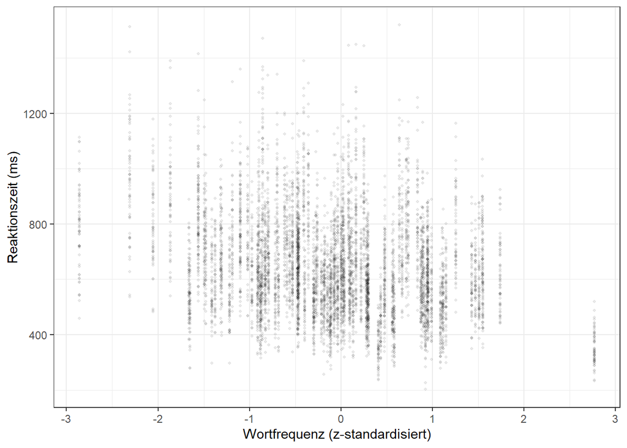

```r
ggplot(
  dat,
  aes(
    x = frequency_z,
    y = RT
  )
) +
  geom_point(
    alpha = .08,
    size = .8
  ) +
  theme_bw() +
  labs(
    x = "Wortfrequenz (z-standardisiert)",
    y = "Reaktionszeit (ms)"
  )
```

Rohdaten zeigen gut:

- Stichprobengröße bzw. Datendichte,
- Streuung,
- Ausreißer,
- die allgemeine Datenstruktur.

Aber dieser Plot zeigt **nicht automatisch den konditionalen Frequency-Effekt aus `m_comm`**, denn das Modell berücksichtigt zusätzlich `condition` und `length_z`.

## 3.3 Rohdatenplot ≠ Modellplot

**WichtigDie zentrale Unterscheidung**

`m_comm` beantwortet nicht einfach:

> Wie sehen die beobachteten RTs bei verschiedenen Frequenzen aus?

Sondern:

> Wie verändert sich die erwartete RT mit Frequency, wenn die anderen Prädiktoren im Modell berücksichtigt werden?

Deshalb sind Rohdaten und Modellvorhersagen **nicht austauschbar**.

## 3.4 Kontinuierlichen Prädiktor modellbasiert visualisieren

Wir erzeugen zunächst Modellvorhersagen:

```r
pred_freq <- as.data.frame(
  ggpredict(
    m_comm,
    terms = "frequency_z [all]"
  )
)

head(pred_freq)
```

```
       x predicted std.error conf.low conf.high group
1 -2.860  775.4623  7.900630 759.9747  790.9498     1
2 -2.306  753.0523  6.535600 740.2406  765.8640     1
3 -2.051  742.7373  5.927362 731.1179  754.3566     1
4 -1.867  735.2942  5.499746 724.5131  746.0754     1
5 -1.661  726.9613  5.035554 717.0901  736.8325     1
6 -1.649  726.4759  5.009074 716.6566  736.2951     1
```

**HinweisAufgabe 11 · Linie + Konfidenzband**

angewandt

Erstelle aus `pred_freq` einen ggplot.

Er soll enthalten:

- die vorhergesagte RT als Linie,
- das 95%-Konfidenzintervall als Band,
- verständliche Achsenbeschriftungen,
- ein zurückhaltendes Theme.

Verwende **nicht** einfach `plot(ggpredict(...))`, sondern baue den Plot selbst.

**TippLösung**

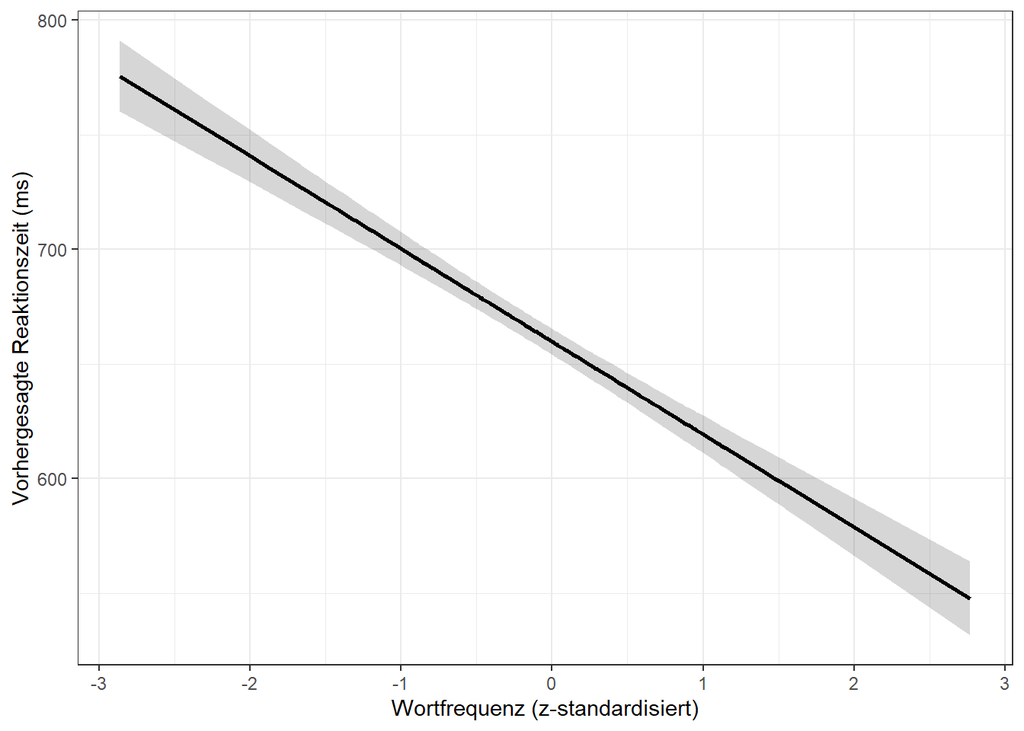

```r
ggplot(
  pred_freq,
  aes(
    x = x,
    y = predicted
  )
) +
  geom_ribbon(
    aes(
      ymin = conf.low,
      ymax = conf.high
    ),
    alpha = .2
  ) +
  geom_line(
    linewidth = 1
  ) +
  theme_bw() +
  labs(
    x = "Wortfrequenz (z-standardisiert)",
    y = "Vorhergesagte Reaktionszeit (ms)"
  )
```

Die Linie zeigt die **vom Modell erwartete Veränderung**.

Das Band zeigt die Unsicherheit der **geschätzten mittleren Vorhersage**.

## 3.5 Extra: Rohdaten und Modell kombinieren

**HinweisExtra 2 · Wie viel Rohdaten braucht ein Ergebnisplot?**

extra

Ergänze den modellbasierten Plot um Rohdaten im Hintergrund.

Experimentiere mit `alpha` und `size`.

Wann helfen die Rohdaten? Wann erschweren sie die Lesbarkeit?

**TippLösung**

Zum Beispiel:

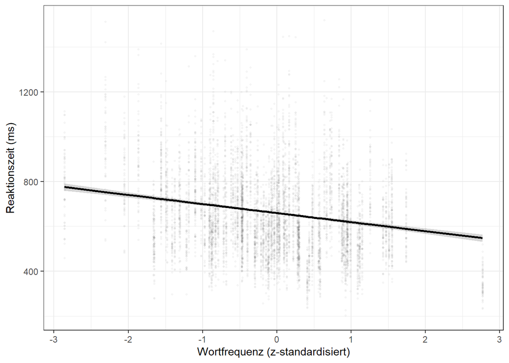

```r
ggplot() +
  geom_point(
    data = dat,
    aes(
      x = frequency_z,
      y = RT
    ),
    alpha = .03,
    size = .6
  ) +
  geom_ribbon(
    data = pred_freq,
    aes(
      x = x,
      ymin = conf.low,
      ymax = conf.high
    ),
    alpha = .2
  ) +
  geom_line(
    data = pred_freq,
    aes(
      x = x,
      y = predicted
    ),
    linewidth = 1
  ) +
  theme_bw() +
  labs(
    x = "Wortfrequenz (z-standardisiert)",
    y = "Reaktionszeit (ms)"
  )
```

Bei großen Datensätzen kann weniger mehr sein. Rohdaten sollten die Modellaussage **unterstützen**, nicht überdecken.

## 3.6 Kategorialen Prädiktor modellbasiert darstellen

```r
pred_condition <- as.data.frame(
  ggpredict(
    m_comm,
    terms = "condition"
  )
)

pred_condition
```

```
          x predicted std.error conf.low conf.high group
1 unrelated  664.6475  2.866629 659.0281  670.2669     1
2   related  629.3764  2.866629 623.7570  634.9958     1
```

**HinweisAufgabe 12 · Punkte statt reflexhaft Balken**

angewandt

Visualisiere die vorhergesagten RTs der beiden Bedingungen.

Verwende:

- Punkte für die Modellvorhersagen,
- Fehlerbalken für die Konfidenzintervalle.

Warum ist ein Balkendiagramm hier nicht erforderlich?

**TippLösung**

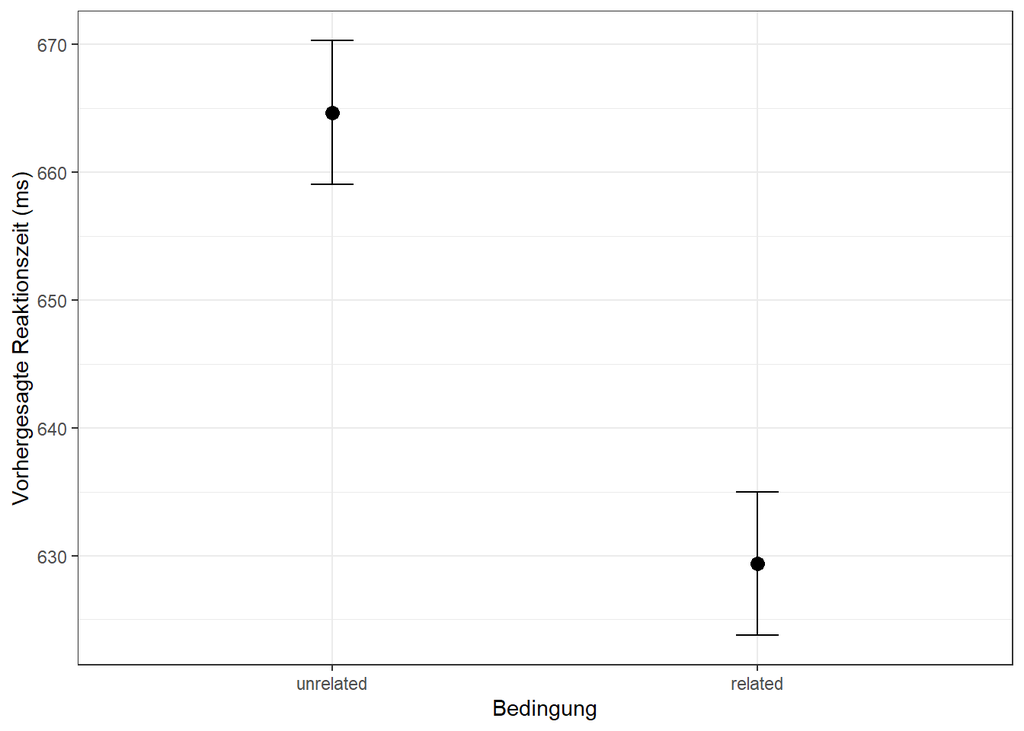

```r
ggplot(
  pred_condition,
  aes(
    x = x,
    y = predicted
  )
) +
  geom_errorbar(
    aes(
      ymin = conf.low,
      ymax = conf.high
    ),
    width = .1
  ) +
  geom_point(
    size = 3
  ) +
  theme_bw() +
  labs(
    x = "Bedingung",
    y = "Vorhergesagte Reaktionszeit (ms)"
  )
```

Ein Balken kodiert zusätzlich die Fläche zwischen 0 und dem geschätzten Wert. Für einen modellbasierten Punktschätzer mit Unsicherheit ist diese Fläche normalerweise nicht die relevante Information.

Punkt + CI zeigt direkter, **wo die Schätzung liegt und wie unsicher sie ist**.

## 3.7 Interaktionen sichtbar machen

```r
pred_int <- as.data.frame(
  ggpredict(
    m_int,
    terms = c(
      "frequency_z [all]",
      "condition"
    )
  )
)

head(pred_int)
```

```
       x predicted std.error conf.low conf.high     group
1 -2.860  810.4037  9.863683 791.0680  829.7394 unrelated
2 -2.860  705.2497  9.863683 685.9140  724.5854   related
3 -2.306  780.9276  8.055694 765.1361  796.7191 unrelated
4 -2.306  689.9059  8.055694 674.1144  705.6974   related
5 -2.051  767.3601  7.240950 753.1657  781.5545 unrelated
6 -2.051  682.8433  7.240950 668.6489  697.0377   related
```

**HinweisAufgabe 13 · Interaktionsplot selbst bauen**

angewandt

Visualisiere den Zusammenhang zwischen Frequency und RT getrennt nach Condition.

Nutze mindestens:

- `linetype = group`,
- eine eigene Linie pro Bedingung,
- Konfidenzbänder,
- eine verständliche Legendenüberschrift.

Was wird im Plot unmittelbar sichtbar, das im Koeffiziententableau schwerer zu erkennen ist?

**TippLösung**

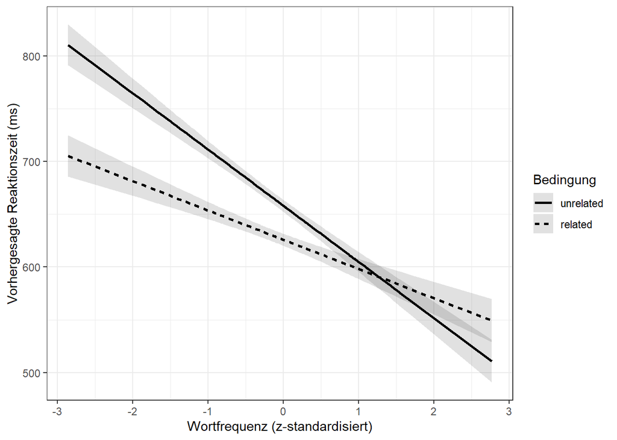

```r
ggplot(
  pred_int,
  aes(
    x = x,
    y = predicted,
    linetype = group
  )
) +
  geom_ribbon(
    aes(
      ymin = conf.low,
      ymax = conf.high,
      group = group
    ),
    alpha = .15
  ) +
  geom_line(
    linewidth = 1
  ) +
  theme_bw() +
  labs(
    x = "Wortfrequenz (z-standardisiert)",
    y = "Vorhergesagte Reaktionszeit (ms)",
    linetype = "Bedingung"
  )
```

Im Plot wird die zentrale Interaktionsaussage unmittelbar sichtbar:

> Die **Steigungen unterscheiden sich zwischen den Bedingungen**.

Genau deshalb sind Interaktionen oft besonders dankbar für Visualisierungen.

## 3.8 Logistische Regression: auf welcher Skala?

```r
pred_log <- as.data.frame(
  ggpredict(
    m_log,
    terms = c(
      "frequency_z [all]",
      "condition"
    )
  )
)
```

**HinweisAufgabe 14 · Wahrscheinlichkeit statt Log-Odds**

angewandt

Erstelle einen modellbasierten Ergebnisplot für `m_log`.

Die y-Achse soll die **vorhergesagte Wahrscheinlichkeit einer korrekten Antwort** zeigen.

Setze die y-Achse sinnvoll auf 0 bis 1.

Warum ist diese Skala für die meisten Zielgruppen kommunikativer als Log-Odds?

**TippLösung**

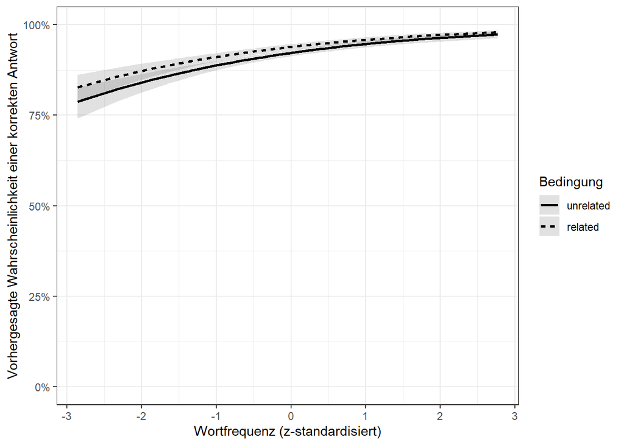

```r
ggplot(
  pred_log,
  aes(
    x = x,
    y = predicted,
    linetype = group
  )
) +
  geom_ribbon(
    aes(
      ymin = conf.low,
      ymax = conf.high,
      group = group
    ),
    alpha = .15
  ) +
  geom_line(
    linewidth = 1
  ) +
  scale_y_continuous(
    limits = c(0, 1),
    labels = scales::percent
  ) +
  theme_bw() +
  labs(
    x = "Wortfrequenz (z-standardisiert)",
    y = "Vorhergesagte Wahrscheinlichkeit einer korrekten Antwort",
    linetype = "Bedingung"
  )
```

Wahrscheinlichkeiten sind für die meisten Leser*innen unmittelbar interpretierbar. Log-Odds sind mathematisch praktisch, aber als kommunikative Skala meist unnötig abstrakt.

## 3.9 Einen schlechten Ergebnisplot redigieren

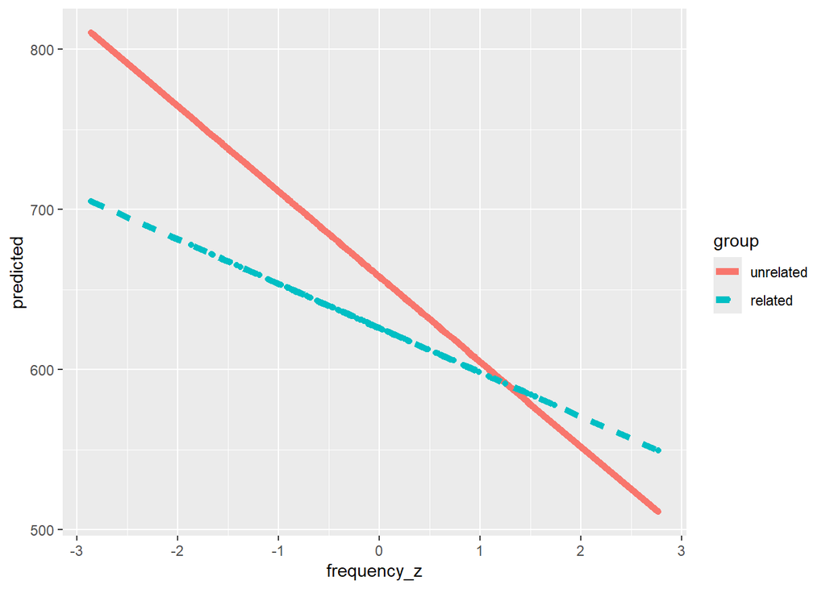

```r
bad_plot <- ggplot(
  pred_int,
  aes(
    x = x,
    y = predicted,
    colour = group,
    linetype = group
  )
) +
  geom_line(
    linewidth = 2
  ) +
  geom_point() +
  labs(
    x = "frequency_z",
    y = "predicted",
    colour = "group",
    linetype = "group"
  ) +
  theme_gray()

bad_plot
```

**HinweisAufgabe 15 · Statistisch korrekt, kommunikativ schwach**

Redaktionsaufgabe

Der Plot ist nicht grundsätzlich statistisch falsch. Verbessere ihn aber für eine wissenschaftliche Ergebnisdarstellung.

Prüfe:

1. technische Variablennamen,
2. redundante Kodierung,
3. unnötige grafische Elemente,
4. Legende,
5. Linienbreite,
6. Unsicherheit,
7. Theme.

Erstelle deine eigene verbesserte Version.

**TippEine mögliche Lösung**

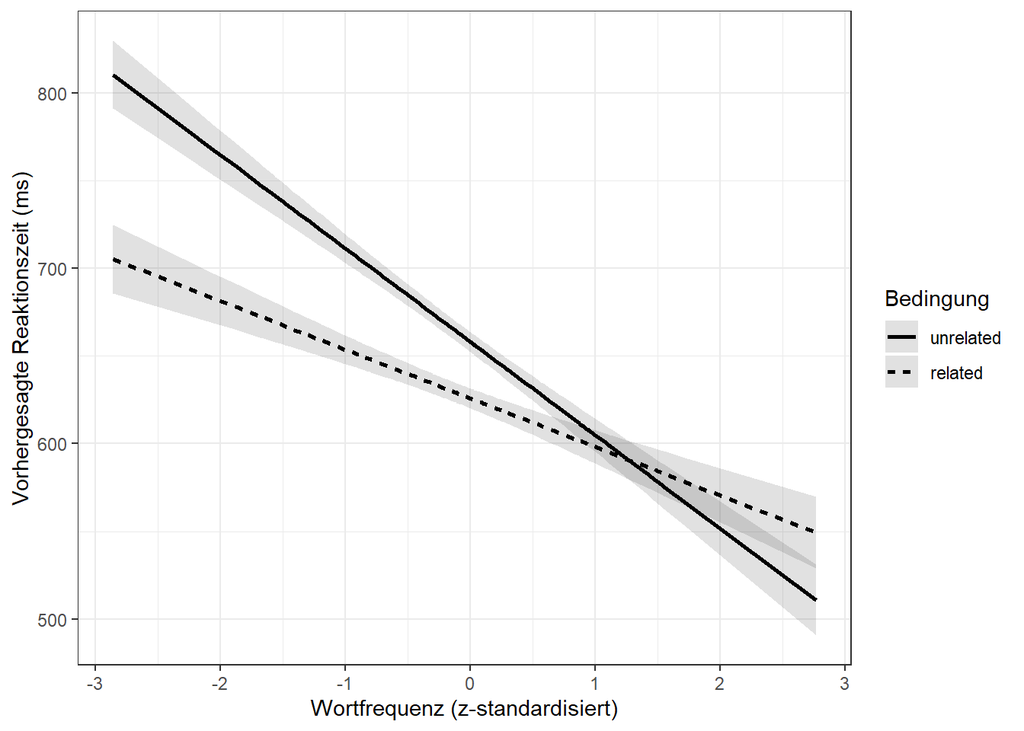

```r
ggplot(
  pred_int,
  aes(
    x = x,
    y = predicted,
    linetype = group
  )
) +
  geom_ribbon(
    aes(
      ymin = conf.low,
      ymax = conf.high,
      group = group
    ),
    alpha = .15
  ) +
  geom_line(
    linewidth = 1
  ) +
  theme_bw() +
  labs(
    x = "Wortfrequenz (z-standardisiert)",
    y = "Vorhergesagte Reaktionszeit (ms)",
    linetype = "Bedingung"
  )
```

Das ist nur **eine** gute Lösung.

Wichtiger als ein bestimmtes Theme ist:

> Jede grafische Entscheidung sollte eine kommunikative Funktion haben.

## 3.10 Extra: eine Publikationsabbildung exportieren

**HinweisExtra 3 · ggsave() bewusst einsetzen**

extra

Speichere einen deiner Ergebnisplots mit `ggsave()`.

Nutze beispielsweise:

- sinnvolle physische Maße,
- ein Vektorformat wie `.svg` oder `.pdf`,
- einen aussagekräftigen Dateinamen.

Warum ist `plot_final_final2.png` keine optimale Strategie?

**TippLösung**

Beispiel:

```r
p_frequency <- ggplot(
  pred_freq,
  aes(
    x = x,
    y = predicted
  )
) +
  geom_ribbon(
    aes(
      ymin = conf.low,
      ymax = conf.high
    ),
    alpha = .2
  ) +
  geom_line(
    linewidth = 1
  ) +
  theme_bw() +
  labs(
    x = "Wortfrequenz (z-standardisiert)",
    y = "Vorhergesagte Reaktionszeit (ms)"
  )

ggsave(
  "frequency_effect_modelplot.svg",
  plot = p_frequency,
  width = 14,
  height = 10,
  units = "cm"
)
```

Reproduzierbare Dateinamen und reproduzierbarer Plot-Code sparen spätestens bei Revisionen sehr viel Zeit.

# 4 Alles zusammenführen

## 4.1 Text, Tabelle und Abbildung erzählen dieselbe Geschichte

**WichtigAufgabe 16 · Drei Darstellungsformen, drei Funktionen**

Transfer

Nutze `m_int`.

Erstelle eine kleine Ergebnisdarstellung aus:

1. **zwei bis drei Sätzen Text**
2. **einer kompakten Tabelle**
3. **einer Abbildung**

Dabei sollen sich die drei Teile **ergänzen**, nicht vollständig duplizieren.

Überlege für jede Information:

> Wo ist sie am besten aufgehoben?

**TippEine mögliche Aufteilung**

**Text**

- zentrale inhaltliche Aussage
- Richtung der Interaktion
- zentrale Effektgröße und Testergebnis

**Tabelle**

- exakte Koeffizienten
- SE / CI
- Teststatistiken und p-Werte
- Referenzkategorie

**Abbildung**

- Form des Interaktionsmusters
- unterschiedliche Steigungen
- Unsicherheit als Konfidenzband

So erzählen alle drei dieselbe Geschichte, aber mit unterschiedlichen Stärken.

# 5 Transfer: Tonal Alignment in German

Wir verwenden mit `data_t` einen neuen Datensatz aus **SfL**.

```r
data(data_t)

str(data_t)
```

```
'data.frame':   544 obs. of  15 variables:
 $ speaker : Factor w/ 12 levels "AE","AM","CB",..: 1 2 3 6 7 9 10 12 5 1 ...
 $ word_dur: num  316 330 229 290 270 ...
 $ vowel   : Factor w/ 3 levels "a","e","i": 1 1 1 1 1 1 1 1 1 1 ...
 $ sylnum  : int  1 1 1 1 1 1 1 1 1 1 ...
 $ sylstr  : Factor w/ 3 levels "double","open",..: 2 2 2 2 2 2 2 2 2 2 ...
 $ C1_dur  : num  81.6 83.6 71.4 72.5 64.2 ...
 $ V1_dur  : num  234 246 157 217 206 ...
 $ C2_dur  : num  0 0 0 0 0 0 0 0 0 0 ...
 $ C3_dur  : num  0 0 0 0 0 0 0 0 0 0 ...
 $ W_dur   : num  0 0 0 0 0 0 0 0 0 0 ...
 $ A1_dur  : num  0 0 0 0 0 0 0 0 0 0 ...
 $ L_dur   : num  0 0 0 0 0 0 0 0 0 0 ...
 $ A2_dur  : num  0 0 0 0 0 0 0 0 0 0 ...
 $ L_time  : chr  "2.458" "45.531" "136.397" "2.377" ...
 $ L_freq  : int  7 -5 24 20 29 -16 -9 -76 44 1 ...
```

Der Datensatz enthält unter anderem:

- `speaker`: Versuchsperson
- `sylstr`: Silbenstruktur
- `L_freq`: Frequenz des niedrigsten F0-Punktes
- verschiedene segmentale Dauervariablen

Eine mögliche Forschungsfrage lautet:

> **Unterscheidet sich die Frequenz des F0-Tiefpunkts in Abhängigkeit von der Silbenstruktur?**

**WichtigTransfer 1 · Von der Analyse zur fertigen Ergebnisdarstellung**

Transfer

Bearbeite diese Aufgabe möglichst selbstständig.

1. Inspiziere `sylstr` und `L_freq`.
2. Visualisiere zunächst die **Rohdaten** sinnvoll.
3. Spezifiziere ein geeignetes Modell für `L_freq`.
   - Berücksichtige, dass mehrere Beobachtungen von denselben Sprecher*innen stammen.
4. Prüfe den Modelloutput.
5. Erzeuge **modellbasierte Vorhersagen** für `sylstr`.
6. Erstelle daraus einen Ergebnisplot mit ggplot.
7. Erstelle eine kleine Ergebnistabelle.
8. Formuliere zwei bis vier Ergebnissätze.

Am Ende sollen Text, Tabelle und Abbildung gemeinsam beantworten:

- Was wurde analysiert?
- Was wurde gefunden?
- Wie groß und wie sicher ist das Muster?

**TippEine mögliche Herangehensweise**

Zunächst:

```r
table(data_t$sylstr)
```

```
double   open single
   186    178    180
```

```r
summary(data_t$L_freq)
```

```
    Min.  1st Qu.   Median     Mean  3rd Qu.     Max.
-90.0000 -17.0000   6.0000   0.1544  24.0000 101.0000
```

Ein Rohdatenplot könnte beispielsweise so aussehen:

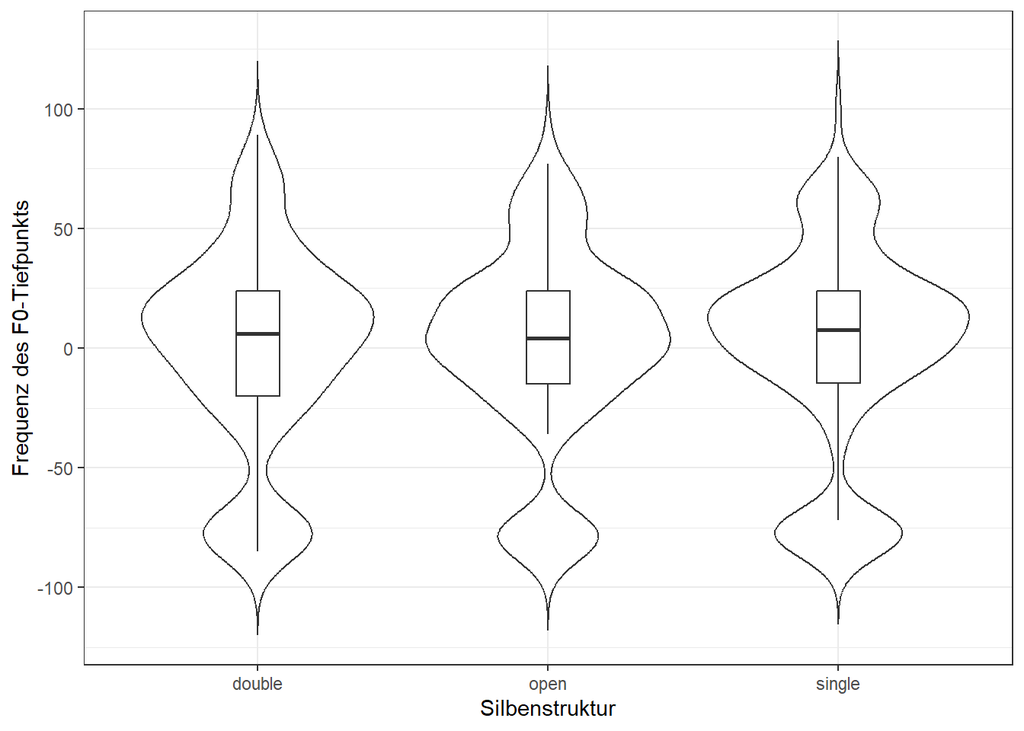

```r
ggplot(
  data_t,
  aes(
    x = sylstr,
    y = L_freq
  )
) +
  geom_violin(
    trim = FALSE
  ) +
  geom_boxplot(
    width = .15,
    outlier.shape = NA
  ) +
  theme_bw() +
  labs(
    x = "Silbenstruktur",
    y = "Frequenz des F0-Tiefpunkts"
  )
```

Ein möglicher Ausgangspunkt für die Analyse:

```r
m_transfer <- lmer(
  L_freq ~
    sylstr +
    (1 | speaker),
  data = data_t
)

summary(m_transfer)
```

```
Linear mixed model fit by REML. t-tests use Satterthwaite's method [
lmerModLmerTest]
Formula: L_freq ~ sylstr + (1 | speaker)
   Data: data_t

REML criterion at convergence: 4082.5

Scaled residuals:
    Min      1Q  Median      3Q     Max
-3.0186 -0.6062 -0.0397  0.6045  3.7137

Random effects:
 Groups   Name        Variance Std.Dev.
 speaker  (Intercept) 1937.00  44.011
 Residual               93.76   9.683
Number of obs: 544, groups:  speaker, 12

Fixed effects:
              Estimate Std. Error        df t value Pr(>|t|)
(Intercept)    0.03378   12.72507  11.04323   0.003   0.9979
sylstropen     0.08872    1.01860 530.00737   0.087   0.9306
sylstrsingle   1.80991    1.01395 530.00188   1.785   0.0748 .
---
Signif. codes:  0 '***' 0.001 '**' 0.01 '*' 0.05 '.' 0.1 ' ' 1

Correlation of Fixed Effects:
            (Intr) sylstrp
sylstropen  -0.039
sylstrsingl -0.039  0.488
```

Modellvorhersagen:

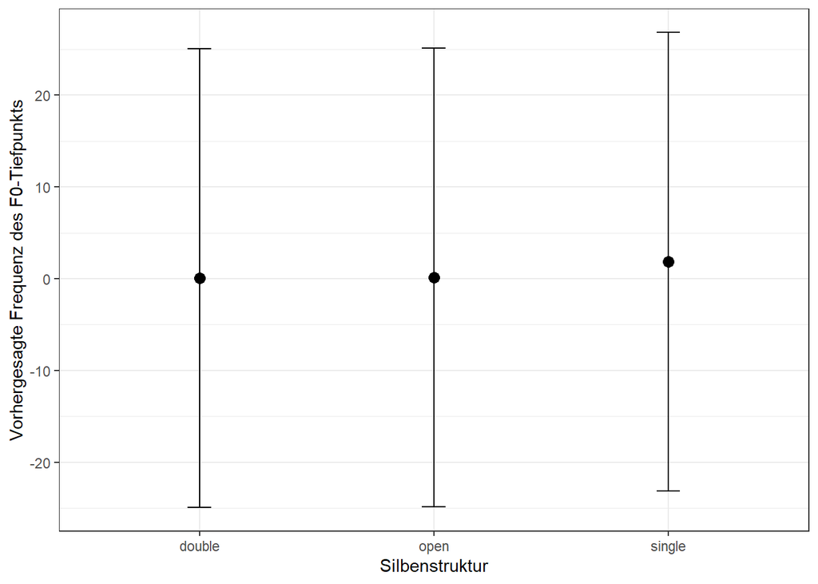

```r
pred_transfer <- as.data.frame(
  ggpredict(
    m_transfer,
    terms = "sylstr"
  )
)

ggplot(
  pred_transfer,
  aes(
    x = x,
    y = predicted
  )
) +
  geom_errorbar(
    aes(
      ymin = conf.low,
      ymax = conf.high
    ),
    width = .1
  ) +
  geom_point(
    size = 3
  ) +
  theme_bw() +
  labs(
    x = "Silbenstruktur",
    y = "Vorhergesagte Frequenz des F0-Tiefpunkts"
  )
```

Wichtig: Der Rohdatenplot und der Modellplot beantworten **unterschiedliche Fragen**. Entscheide bewusst, welcher davon die zentrale Ergebnisabbildung sein sollte.

## 5.1 Extra: Zielgruppe ändern

**HinweisExtra 4 · Dasselbe Ergebnis für zwei Zielgruppen**

extra

Nimm das Ergebnis aus dem `data_t`-Transfer und kommuniziere es zweimal:

**Version A:** für ein quantitativ arbeitendes linguistisches Fachpublikum  
**Version B:** für eine kurze mündliche Präsentation vor einem gemischten Publikum

Was würdest du bei

- Text,
- Tabelle,
- Abbildung

jeweils verändern?

## 5.2 Extra: Reviewer-Modus

**HinweisExtra 5 · Finde die Kommunikationsprobleme**

extra

Stell dir vor, ein Paper enthält:

- im Text nur den p-Wert,
- eine Tabelle mit 12 Dezimalstellen,
- einen Boxplot mit Rohmittelwerten für ein multiples Regressionsmodell,
- eine Interaktion, die nur über den einzelnen Interaktionskoeffizienten beschrieben wird,
- keine Angabe der Referenzkategorie.

Schreibe fünf kurze Reviewer-Kommentare: Was sollte jeweils verbessert werden?

**TippLösungsideen**

Mögliche Hinweise:

1. Effektgröße und Unsicherheit zusätzlich zum p-Wert berichten.
2. Dezimalstellen auf sinnvolle Genauigkeit reduzieren.
3. Modellbasierte statt ausschließlich rohe Zusammenfassungen zeigen, wenn die kontrollierte Modellschätzung kommuniziert werden soll.
4. Interaktion zusätzlich visualisieren und bedingte Effekte verständlich beschreiben.
5. Referenzkategorie explizit nennen.

Der gemeinsame Nenner:

> Leser*innen sollten nicht den R-Code rekonstruieren müssen, um zu verstehen, was das Ergebnis bedeutet.

# 6 Take-home

**WichtigWas soll nach diesem Block hängen bleiben?**

- Gute Ergebnisdarstellung beantwortet: **Was wurde analysiert? Was wurde gefunden? Wie groß und wie sicher ist der Befund?**
- Ergebnisse beschreiben Befunde; die Diskussion erklärt und kontextualisiert sie.
- Ein Ergebnis besteht nicht nur aus einem p-Wert.
- Tabellen sind **redigierte wissenschaftliche Darstellungen**, kein kopierter R-Output.
- Rohdatenplots und Modellplots beantworten oft unterschiedliche Fragen.
- Modellplots sollten Vorhersagen und ihre **Unsicherheit** sichtbar machen.
- Bei logistischer Regression ist die Wahrscheinlichkeit meist kommunikativer als Log-Odds.
- Interaktionen profitieren besonders von Visualisierung.
- Gute ggplots haben eine klare Aussage und verwenden grafische Mittel **funktional statt dekorativ**.
- Text, Tabelle und Abbildung sollten dieselbe Geschichte erzählen, ohne sich vollständig zu wiederholen.